# Module 4 Solutions

- Show All Code
- Hide All Code
- View Source

## Data set-up

See Module 1 Exercise Solutions for recommendations on how to import data.

The following packages were used for the solutions.

````markdown
```{r}
# Load libraries
library(tidyverse) # for data manipulation
library(skimr) # for skim() to summarise datasets
library(labelled) # for generate_dictionary() to view value labels
library(janitor) # for tabyl() to create frequency tables
library(lubridate) # for working with date variables
library(survival) # for survival analysis
library(broom) # to summarise model functions
```
````

We import the data as provided in the Module 4 exercises.

1. All hospital admissions for patient subset

**Show R code**

```r
## Read in csv file
apdc_subset <- read_csv("https://raw.githubusercontent.com/NicoleDeLaMata/LinkedData/refs/heads/main/apdc_subset.csv")

## Convert date variables to date format then sort the data
apdc_subset <- apdc_subset %>%
  mutate(episode_start_date = dmy(episode_start_date),
         episode_end_date = dmy(episode_end_date)) %>%
  arrange(ppn, episode_start_date, episode_end_date)
```

2. Hospital admissions relating to patients first kidney transplant only

**Show R code**

```r
## Create a flag for patients with any admissions related to kidney transplant
diag_vars <- paste0("diagnosis_code", c("P", seq(1, 19)))
diag_vars
```

```
 [1] "diagnosis_codeP"  "diagnosis_code1"  "diagnosis_code2"  "diagnosis_code3"
 [5] "diagnosis_code4"  "diagnosis_code5"  "diagnosis_code6"  "diagnosis_code7"
 [9] "diagnosis_code8"  "diagnosis_code9"  "diagnosis_code10" "diagnosis_code11"
[13] "diagnosis_code12" "diagnosis_code13" "diagnosis_code14" "diagnosis_code15"
[17] "diagnosis_code16" "diagnosis_code17" "diagnosis_code18" "diagnosis_code19"
```

**Show R code**

```r
ktx_codes <- c("Z94")

analysis_ktx_data <- apdc_subset %>%
  mutate(ktx = 1 * if_any(all_of(diag_vars), ~ str_sub(.x, 1, 3) %in% ktx_codes))

## Create analysis dataset restricted to episodes of care related to kidney transplant
analysis_ktx_data1 <- analysis_ktx_data %>%
  filter(ktx == 1) %>%
  arrange(ppn, episode_start_date, episode_end_date) %>%
  group_by(ppn) %>%
  filter(row_number() == 1) %>%
  ungroup()
```

3. Death records relating to patient subset

**Show R code**

```r
## Read in csv file
dth_tx_subset <- read_csv("https://raw.githubusercontent.com/NicoleDeLaMata/LinkedData/refs/heads/main/dth_tx_subset.csv")
```

## Question 1

Apply the provided transfers code *transfers()* to add variables to all hospital admissions dataset (**apdc_subset**) to identify which episodes of care belong to the same hospital admission.

How many periods of stay contained one or more transfers? What is the maximum number of transfers?

**Show R code**

```r
## Load transfers package
library(devtools)
install_github("james-hedley/transfers")
library(transfers)

## Identify transfers in the analysis dataset
apdc_subset <- apdc_subset %>%
  transfers(id = "ppn",
                admdate = "episode_start_date",
                sepdate = "episode_end_date",
                mode = "mode_of_separation_recode")

## Check transseq
apdc_subset %>% tabyl(transseq)
```

```
 transseq    n      percent
        0 6739 0.9353226926
        1  336 0.0466342817
        2   67 0.0092990978
        3   26 0.0036086051
        4   14 0.0019430951
        5   10 0.0013879251
        6    7 0.0009715475
        7    2 0.0002775850
        8    1 0.0001387925
        9    1 0.0001387925
       10    1 0.0001387925
       11    1 0.0001387925
```

There should be 6,739 *transseq* values of 0. 336 admissions (periods of stay) contained 1 or more transfers (transseq = 1). The maximum number of transfers within any admission was 11.

## Question 2

Only keep hospital admissions occurring after the first kidney transplant data, as given by the episode_start_date from the **analysis_ktx_data1** dataset.

How many patients with first kidney transplant were there? How many patients had hospital admissions after their first kidney transplant?

**Show R code**

```r
##Check there are 88 patients from analysis_ktx_data1
analysis_ktx_data1 %>% distinct(ppn) %>% nrow()
```

```
[1] 88
```

**Show R code**

```r
##Merge in date of first kidney transplant
apdc_aftertx <- analysis_ktx_data1 %>%
                mutate(tx_date=episode_end_date) %>%
                select(ppn, tx_date) %>%
                right_join(apdc_subset, by="ppn") %>%
                filter(admdate_first>tx_date | (admdate_first<=tx_date & sepdate_last>tx_date))

##Check number of patients with hospital admissions after kidney transplant
apdc_aftertx %>% distinct(ppn) %>% nrow()
```

```
[1] 85
```

There are 88 patients with a hospital admission relating to their first kidney transplant. Our hospital admissions dataset (**apdc_subset**) reduces from 7205 episodes of care to 1144 episodes of care after first kidney transplant. There were 85 patients in this resulting dataset, suggesting 3 people with first kidney transplant did not have a subsequent hospital admission.

## Question 3

Using the resulting dataset from Question 2, identify hospital admissions that related to cardiovascular disease in any of the diagnosis fields. Cardiovascular disease is defined by ICD-10-AM codes including I20-I25, I34-I37, I42, I44-I49, I60-I61, and I63. Create a *cvd_flag* variable that takes a value of 1 for admissions relating to cardiovascular disease.

How many hospital admissions relating to cardiovascular disease were there after patients had their first kidney transplant?

**Show R code**

```r
## Create a flag for patients with any admissions related to ischemic heart disease
diag_vars <- paste0("diagnosis_code", c("P", seq(1, 19)))
diag_vars
```

```
 [1] "diagnosis_codeP"  "diagnosis_code1"  "diagnosis_code2"  "diagnosis_code3"
 [5] "diagnosis_code4"  "diagnosis_code5"  "diagnosis_code6"  "diagnosis_code7"
 [9] "diagnosis_code8"  "diagnosis_code9"  "diagnosis_code10" "diagnosis_code11"
[13] "diagnosis_code12" "diagnosis_code13" "diagnosis_code14" "diagnosis_code15"
[17] "diagnosis_code16" "diagnosis_code17" "diagnosis_code18" "diagnosis_code19"
```

**Show R code**

```r
cvd_codes <- c("I20", "I21", "I22", "I24", "I25", "I34", "I35", "I36", "I37", "I42", "I44", "I45", "I46", "I47", "I48", "I49", "I60", "I61", "I63")

apdc_aftertx <- apdc_aftertx %>%
  mutate(cvd_flag = 1 * if_any(all_of(diag_vars), ~ str_sub(.x, 1, 3) %in% cvd_codes))

## Create a one-way frequency table of ihd to check that flag has been created correctly
apdc_aftertx %>% tabyl(cvd_flag)
```

```
 cvd_flag    n   percent
        0 1016 0.8881119
        1  128 0.1118881
```

There were 128 hospital records relating to cardiovascular disease.

## Question 4

Recall that we have already applied the transfers code *transfers()* in case any transfers occurred during the first kidney transplant and to ensure we captured the correct subsequent hospital admissions. However, as we then kept only hospital admissions following the first kidney transplant, several of the newly created variables would not technically still be correct.

*fileseq* would not be correct as we removed observations. *episode* and *stayseq* may be correct in certain circumstances (i.e. if their first hospital admission for the data period was the first kidney transplant) but generally would not always - although it is consecutively correct, it would not always start from 1 for the first observation for a patient. *transfer, transseq, admdate_first, sepdate_last* and *totlos* would all be correct.

Keeping this in mind, let’s start by reducing our dataset to the necessary variables (i.e. *ppn, stayseq, admdate_first, sepdate_last, totlos* and *cvd_flag*) and removing duplicates.Consider any additional data checks you may need to undertake to ensure the resulting dataset has one row per ppn per hospital admission. Then, we will recreate *fileseq* and create an index sequence varaible (*index_seq*) to flag the first admission with cardiovascular disease (if any) for each patient using the *cvd_flag*.

**Show R code**

```r
# Keep necessary variables and de-duplicate rows
apdc_aftertx_red <- apdc_aftertx %>%
  select(ppn, stayseq, admdate_first, sepdate_last, totlos, cvd_flag) %>%
  distinct()
```

Let’s check if this has worked as we expected. There should not be any duplicated *ppn* and *stayseq* - could you think of scenarios where they may be?

**Show R code**

```r
# Check if there is duplicated rows for ppn and stayseq
check <-  apdc_aftertx_red %>%
  group_by(ppn, stayseq) %>%
  filter(n() > 1) %>%
  ungroup()
```

We see here that cvd_flag was 1 for only one row of the same admission, which could very possibly occur. Let’s amend our coding so we take the observation rows where cvd_flag = 1.

**Show R code**

```r
# Keep necessary variables and de-duplicate rows
apdc_aftertx_red <- apdc_aftertx %>%
  select(ppn, stayseq, admdate_first, sepdate_last, totlos, cvd_flag) %>%
  arrange(ppn, stayseq, -cvd_flag) %>%
  group_by(ppn, stayseq) %>%
  slice(1) %>%
  ungroup

# Re-create file_seq
apdc_aftertx_red <- apdc_aftertx_red %>%
  arrange(ppn, admdate_first) %>%
  mutate(file_seq = row_number())

# Create index_seq
apdc_aftertx_red <- apdc_aftertx_red %>%
  group_by(ppn) %>%
  mutate(cvd_cumcount = cumsum(cvd_flag),
         post_cvd = 1 * (cvd_cumcount > 0)) %>%
  group_by(ppn, post_cvd) %>%
  mutate(index_seq = row_number() * post_cvd) %>%
  ungroup()

# Check index_seq
apdc_aftertx_red %>% skim(index_seq)
```

Data summary

| Name | Piped data |
| --- | --- |
| Number of rows | 1086 |
| Number of columns | 10 |
| _______________________ |  |
| Column type frequency: |  |
| numeric | 1 |
| ________________________ |  |
| Group variables | None |

**Variable type: numeric**

| skim_variable | n_missing | complete_rate | mean | sd | p0 | p25 | p50 | p75 | p100 | hist |
| --- | --- | --- | --- | --- | --- | --- | --- | --- | --- | --- |
| index_seq | 0 | 1 | 4.37 | 10.02 | 0 | 0 | 0 | 3 | 58 | ▇▁▁▁▁ |

**Show R code**

```r
table(apdc_aftertx_red$index_seq)
```

```
  0   1   2   3   4   5   6   7   8   9  10  11  12  13  14  15  16  17  18  19
750  30  26  22  19  19  17  16  14  12  11   9   8   7   7   7   7   7   7   5
 20  21  22  23  24  25  26  27  28  29  30  31  32  33  34  35  36  37  38  39
  4   4   4   4   4   3   3   3   3   3   3   3   3   3   2   2   2   2   2   2
 40  41  42  43  44  45  46  47  48  49  50  51  52  53  54  55  56  57  58
  2   2   2   2   2   2   2   2   1   1   1   1   1   1   1   1   1   1   1
```

How many patients had at least one hospitalisation relating to cardiovascular disease after kidney transplant?

There were 30 patients with at least one hospitalisation relating to cardiovascular disease after kidney transplant. The maximum number of admissions following a hospitalisation relating to cardiovascular disease was 58.

## Question 5

Retain all the records for patients who had at least one admission relating to cardiovascular disease (i.e. post_cvd = 1) into a new dataframe (**cvd_adm**). How many records are in this dataframe?

**Show R code**

```r
# Only cvd admissions
cvd_adm <- apdc_aftertx_red %>% filter(post_cvd!=0)
```

There are 336 records.

## Question 6

Let’s work on the deaths data (**dth_tx_subset**). Perform data checks (e.g remove duplicates, format dates) and ensure there is only one record per ppn.

**Show R code**

```r
# Remove exact duplicates
dth_tx_subset <- dth_tx_subset %>%
                 mutate(death_date = dmy(death_date)) %>% distinct()

# Find duplicated records
check_dth <-  dth_tx_subset %>%
  group_by(ppn) %>%
  filter(n() > 1) %>%
  ungroup()
```

We see that the non-exact duplicates have occurred due to differences in the order of the secondary causes of death (i.e. *racs1* to *racs8*). As we are not concerned with causes of death for this analysis, let’s remove these variables and de-duplicate the data.

**Show R code**

```r
# Remove exact duplicates
dth_tx_subset2 <- dth_tx_subset %>% select(ppn, age_recode, sex, death_date) %>% distinct()

# Find duplicated records
check_dth <-  dth_tx_subset2 %>%
  group_by(ppn) %>%
  filter(n() > 1) %>%
  ungroup()
```

We no longer have any duplicated ppns. We have a total of 181 deaths.

## Question 7

Merge the deaths data with **cvd_adm**. Ensure you remove any death records that didn’t have a hospitalisation (i.e. left-join with keeping all observations from **cvd_adm**).

**Show R code**

```r
# Merge cvd_adm with dth_tx_subset2
cvd_dth_subset <- cvd_adm %>% left_join(dth_tx_subset2, by = "ppn")
```

## Question 8

We will now be undertaking checks to identify inconsistencies in the death dates with the hospitalisation records, which may indicate a linkage or other error.

First, we need to find and merge in the *mode_of_separation_recode* for the last observation for each ppn and *admdate_first*.

**Show R code**

```r
#Find mode_of_separation_recode for last observation per ppn and admdate_first
mode_sep <- apdc_aftertx %>%
          arrange(ppn, admdate_first, desc(episode_end_date)) %>%
          group_by(ppn, stayseq) %>%
          slice(1) %>%   ungroup() %>%
          select(ppn, stayseq, mode_of_separation_recode)

# Merge in mode_of_separation_recode
cvd_dth_subset <- cvd_dth_subset %>% left_join(mode_sep, join_by(ppn, stayseq))
```

Then, create a separate flag variable for each of the following types of inconsistency and report the total number of cases where these occurred:

**Show R code**

```r
#Ensure dates are formatted
cvd_dth_subset <- cvd_dth_subset %>%
# Check for inconsistencies with death dates
  # a) Mode of separation is death with autopsy, but death date is missing
  mutate(dodgy_flag_a = (mode_of_separation_recode == "6" & is.na(death_date)) * 1) %>%
  # b) Mode of separation is death without autopsy, but death date is missing
  mutate(dodgy_flag_b = (mode_of_separation_recode == "7" & is.na(death_date)) * 1) %>%
  # c) Date of death is before admission
  mutate(dodgy_flag_c = (!is.na(death_date) & (death_date < admdate_first)) * 1) %>%
  # d) Date of death is more than 1 day before separation
  mutate(dodgy_flag_d = (!is.na(death_date) & (death_date < (sepdate_last - 1))) * 1)

# Summarise dodgy records
cvd_dth_subset %>%
  group_by(dodgy_flag_a, dodgy_flag_b, dodgy_flag_c, dodgy_flag_d) %>%
  summarise(n = n()) %>%
  ungroup() %>%
  # Arrange rows in order: no flags, flag a, flag b, flag c, then flag d
  mutate(any_dodgy_flag = pmax(dodgy_flag_a, dodgy_flag_b, dodgy_flag_c, dodgy_flag_d)) %>%
  arrange(any_dodgy_flag, desc(dodgy_flag_a), desc(dodgy_flag_b), desc(dodgy_flag_c), dodgy_flag_d) %>%
  select(-any_dodgy_flag)
```

```
# A tibble: 3 × 5
  dodgy_flag_a dodgy_flag_b dodgy_flag_c dodgy_flag_d     n
         <dbl>        <dbl>        <dbl>        <dbl> <int>
1            0            0            0            0   330
2            0            1            0            0     4
3            0            0            1            1     2
```

**Show R code**

```r
# View dodgy records
cvd_dth_subset %>%
  filter(dodgy_flag_a!=0 | dodgy_flag_b!=0 | dodgy_flag_c!=0 | dodgy_flag_d!=0) %>%
  View()
```

1. Cases where *mode_of_separation_recode* indicates death with autopsy but there is no matching date of death.

There were no cases.

2. Cases where *mode_of_separation_recode* indicates death without autopsy but there is no matching date of death.

There were 4 cases.

3. Cases where the death occurred before admission date.

There were 2 cases.

4. Cases where the death happened before the admission end date. Note that it is possible for date of death to be the day before admission end date, in cases where a patient dies late one day and the body is removed from the hospital the following day. Therefore, only flag those cases where the gap is more than one day.

There were 2 cases.

## Question 9

Examine the records of the flagged patients. What kind of error does this appear to be?

To avoid relying on assumptions, delete all records for those patients flagged as having incorrect death dates.

**Show R code**

```r
# Flag patients with any dodgy records
cvd_dth_subset <- cvd_dth_subset %>%
  group_by(ppn) %>%
  # create  flag = 1 for person, if 1 or more records are dodgy
  mutate(dodgy_person = case_when(
    max(dodgy_flag_a) > 0 ~ 1,
    max(dodgy_flag_b) > 0 ~ 1,
    max(dodgy_flag_c) > 0 ~ 1,
    max(dodgy_flag_d) > 0 ~ 1,
    TRUE ~ 0)) %>%
  ungroup()

# Check all people with any dodgy records
cvd_dth_subset %>%
  filter(dodgy_person == 1) %>%
  select(ppn, admdate_first, sepdate_last,
         mode_of_separation_recode, death_date,
         dodgy_flag_a, dodgy_flag_b, dodgy_flag_c, dodgy_flag_d) %>%
  view()
```

There were 6 PPNs. PPN “5bW4Trp3PCM”, “6O.4rTOZq0O”, “Ke/4jTBLEV9” and “a0pPzqaNAfx” had no death dates recorded. Despite “5bW4Trp3PCM” having over 18 admissions, whilst the other PPNS only had one or two admissions. Similarly, PPN “VM5t/xO0xcB” only had one hospital admission and had a death date assigned prior to this, so perhaps a data linkage error. Finally, PPN “cJDUPD.1/5U” had a death date that aligned with the admission separation date of the second last hospitalisation. This suggests the last admission may be a data linkage error.

**Show R code**

```r
# Delete all records for patients with any incorrect death dates
cvd_dth_subset <- cvd_dth_subset %>% filter(dodgy_person == 0)
```

## Question 10

Create an analysis dataset (**analysis_data**) including only the index admission relating to cardiovascular disease for each patient. Create a *final_date* variable for all patients. This should be the end of the study period (31 December 2020) or their date of death, whichever comes first.

**Show R code**

```r
# Create analysis dataset restricted to index admission
analysis_data <- cvd_dth_subset %>%
  filter(index_seq == 1)

# Create final_date
analysis_data <- analysis_data %>%
  mutate(final_date = pmin(as.Date("2020-12-31"), death_date, na.rm = TRUE))
```

## Question 11

Create the survival time (*survtime*) from *admdate_first* of the index admission until the *final_date* and censoring variable (*status*) to indicate whether the patient died before the end of the study period. If the survtime variable is 0, recode to 1 day. Convert the survival time to be in years, rather than days.

What is the median survival time for those who died compared to those who survived?

**Show R code**

```r
# Create survtime
analysis_data <- analysis_data %>%
  mutate(survtime = as.numeric(final_date - admdate_first),
         survtime = if_else(survtime == 0, 1, survtime),
         survtime = survtime / 365.25)

# Create status
analysis_data <- analysis_data %>%
  mutate(status = case_when(
    is.na(death_date) ~ 0, # If death date is NA, need to explicitly code this as 0 (no death)
    death_date <= final_date ~ 1,
    TRUE ~ 0))

# Summary of survival time by status
analysis_data %>% group_by(status) %>% skim(survtime)
```

Data summary

| Name | Piped data |
| --- | --- |
| Number of rows | 24 |
| Number of columns | 22 |
| _______________________ |  |
| Column type frequency: |  |
| numeric | 1 |
| ________________________ |  |
| Group variables | status |

**Variable type: numeric**

| skim_variable | status | n_missing | complete_rate | mean | sd | p0 | p25 | p50 | p75 | p100 | hist |
| --- | --- | --- | --- | --- | --- | --- | --- | --- | --- | --- | --- |
| survtime | 0 | 0 | 1 | 6.26 | 4.79 | 0.29 | 2.15 | 6.26 | 10.47 | 16.20 | ▇▂▃▅▁ |
| survtime | 1 | 0 | 1 | 2.54 | 2.64 | 0.36 | 0.60 | 0.88 | 4.20 | 6.95 | ▇▁▂▂▂ |

The median survival time was 6.26 years in those who survived and 0.88 years in those who died.

## Question 12

Plot the overall survival curve. Using this plot, what is the approximate survival probability at 5 years?

**Show R code**

```r
# Survival analysis
survfit <- survfit(data = analysis_data,
                   formula = Surv(time = survtime,
                                  event = status) ~ 1)

survfit
```

```
Call: survfit(formula = Surv(time = survtime, event = status) ~ 1,
    data = analysis_data)

      n events median 0.95LCL 0.95UCL
[1,] 24      7     NA    6.95      NA
```

**Show R code**

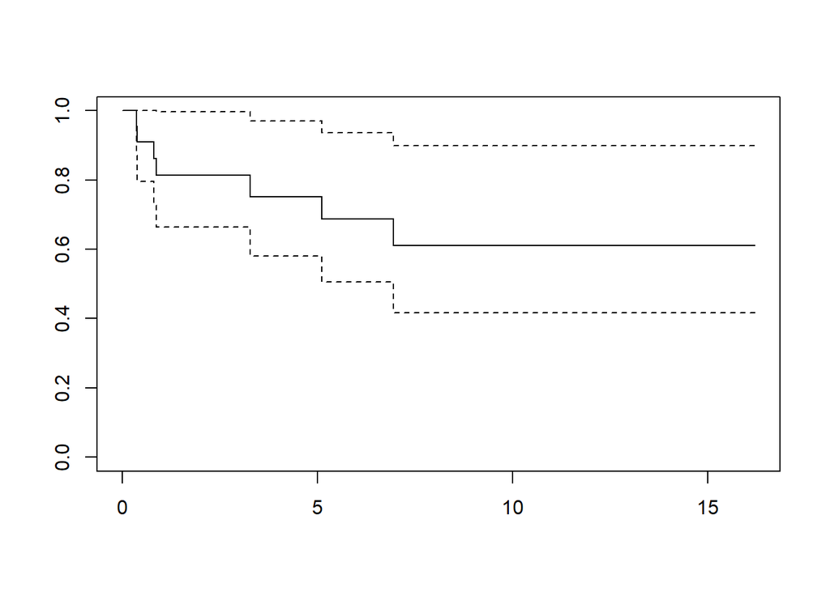

```r
## Quick survival plot
survfit %>% plot()
```

**Show R code**

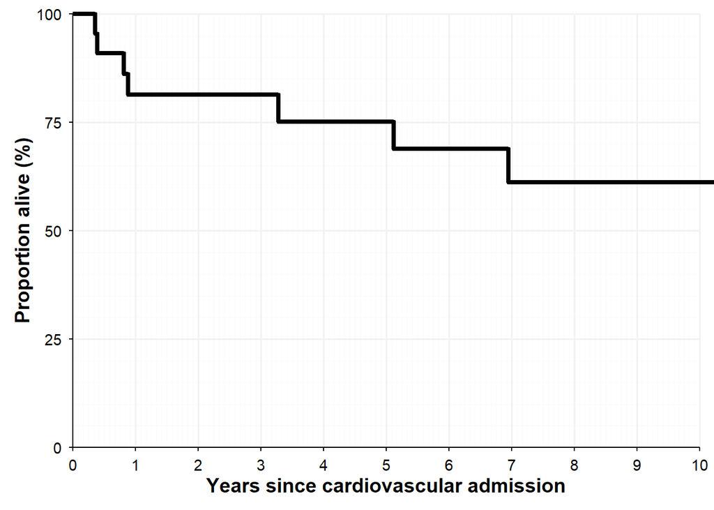

```r
## Nicer looking plot - if interested
plotdata <- tidy(survfit) %>%
  select(time, estimate) %>%
  bind_rows(tibble(time = 0, estimate = 1), .)

ggplot(data = plotdata, mapping = aes(x = time, y = estimate)) +
  geom_step(colour = "black", linewidth = 1.5) +
  xlab("Years since cardiovascular admission") +
  ylab("Proportion alive (%)") +
  coord_cartesian(xlim = c(0, 10),
                  ylim = c(0, 1),
                  clip = "off") +
  scale_x_continuous(breaks = 0:10,
                     minor_breaks = seq(0, 10, 1/12),
                     expand = c(0, 0)) +
  scale_y_continuous(breaks = seq(0, 1, 0.25),
                     labels = seq(0, 100, 25),
                     minor_breaks = seq(0, 1, 0.05),
                     expand = c(0, 0)) +
  theme_minimal() +
  theme(axis.text = element_text(colour = "black", size = 11),
        axis.title = element_text(colour = "black", size = 14, face = "bold"),
        axis.line = element_line(colour = "black"),
        axis.ticks = element_line(colour = "black"),
        panel.grid.major = element_line(colour = "grey95", linewidth = 0.7),
        panel.grid.minor = element_line(colour = "grey98", linewidth = 0.2),
        panel.border = element_blank(),
        plot.margin = margin(t = 10, b = 10, l = 10, r = 10))
```

The approximate survival probability is 75% at 5 years.

## Question 13

Find the probability of patients who survived for:

**Show R code**

```r
# Proportion surviving to each time point
summary(survfit, times = c(0.5, 1, 3))
```

```
Call: survfit(formula = Surv(time = survtime, event = status) ~ 1,
    data = analysis_data)

 time n.risk n.event survival std.err lower 95% CI upper 95% CI
  0.5     19       2    0.909  0.0613        0.797        1.000
  1.0     17       2    0.813  0.0843        0.664        0.997
  3.0     14       0    0.813  0.0843        0.664        0.997
```

1. 6 months.  
   The survival probability is 90.9% (79.7-100.0%) at 6 months.
2. 1 year.  
   The survival probability is 81.3% (66.4-99.7%) at 1 year.
3. 3 years.  
   The survival probability is 81.3% (66.4-99.7%) at 3 years.

**NoteNote**

No further deaths have occurred between 1 year and 3 years, which is why the survival proportion remains unchanged.